# Lab #4

Jung Ho Suh

```r
library(readxl)
defense <- read_excel('cyclonesFootball2020.xlsx', sheet='Defensive')
offense <- read_excel('cyclonesFootball2020.xlsx', sheet='Offensive')
bio <- read_excel('cyclonesFootball2020.xlsx', sheet='Biography')
str(defense)
```

```
## tibble [372 x 11] (S3: tbl_df/tbl/data.frame)
##  $ Name             : chr [1:372] "Rose, Mike" "Rose, Mike" "Rose, Mike" "Rose, Mike" ...
##  $ Opponent_Opponent: chr [1:372] "Louisiana" "TCU" "Oklahoma" "Texas Tech" ...
##  $ Tackles_Solo     : chr [1:372] "2" "6" "6" "3" ...
##  $ Tackles_ASST     : chr [1:372] "4" "4" "5" "0" ...
##  $ Tackles_TFL      : chr [1:372] "1.0" "0" "1.5" "1.0" ...
##  $ Tackles_Sack     : chr [1:372] "0" "0" "0.5" "0" ...
##  $ Turnover_FF      : chr [1:372] "0" "0" "0" "0" ...
##  $ Turnover_FR      : chr [1:372] "0" "0" "0" "0" ...
##  $ Turnover_INT     : chr [1:372] "0" "1" "0" "0" ...
##  $ Pass_QBH         : chr [1:372] "0" "0" "1" "0" ...
##  $ Pass_PB          : chr [1:372] "0" "0" "0" "0" ...
```

*Part one: Cleaning data*

Although the three Excel sheets are loaded into R, they are not useful before some cleaning. Manipulate the three imported data frames:

```
1.The player names and opponent names should be factors.
2.All offensive and defensive statistics should be numerical. The Weight column in biogrpahy should also be numeric. (Optional: Read ?across and learn to mutate multiple columns simultaneously using the across function in dplyr)
3.The Height column in biography should be numeric. (Hint: Use a unit that works well)
4.Add a column to both defense and offense indicating whether it is the first or the second game versus an opponent. We had a single game versus each opponent except for Oklahoma, which we played against twice. (Hint: You can use group_by(), mutate(), and row_number())
```

By cleaning the three data frames in R, at the end of this step you should have the following three clean data frames: defClean, offClean, and bioClean. Print the structures of these data frames using str().

```r
library(dplyr)
```

```r
library(tidyr)
defense <- read_excel('cyclonesFootball2020.xlsx', sheet='Defensive')
offense <- read_excel('cyclonesFootball2020.xlsx', sheet='Offensive')
bio <- read_excel('cyclonesFootball2020.xlsx', sheet='Biography')

#mutate(across(1:Sepal.Width, round))
#mutate(across(c(1, 2), round))

defClean <- defense %>%  mutate_at(vars(Name, Opponent_Opponent), as.factor) %>% mutate(across(Tackles_Solo:Pass_PB, as.numeric)) %>% group_by(Name, Opponent_Opponent) %>% mutate(num_game = row_number())

offClean <- offense %>%  mutate_at(vars(Name, Opponent_Opponent), as.factor) %>% mutate(across(Receiving_REC:Passing_INT, as.numeric)) %>% group_by(Name, Opponent_Opponent) %>% mutate(num_game = row_number())
bioClean <- bio %>%  mutate_at(vars(Name), as.factor) %>% separate(Height, c('feet','inch'), sep = '-', convert = TRUE, remove = FALSE) %>% mutate(Height = 12*feet+inch) %>% mutate(across(Height:Weight, as.numeric))

str(defClean)
```

```
## grouped_df [372 x 12] (S3: grouped_df/tbl_df/tbl/data.frame)
##  $ Name             : Factor w/ 37 levels "Akers, Landen",..: 26 26 26 26 26 26 26 26 26 26 ...
##  $ Opponent_Opponent: Factor w/ 11 levels "Baylor","Kansas",..: 4 8 5 10 6 2 1 3 9 11 ...
##  $ Tackles_Solo     : num [1:372] 2 6 6 3 7 4 7 4 4 2 ...
##  $ Tackles_ASST     : num [1:372] 4 4 5 0 3 1 4 3 9 3 ...
##  $ Tackles_TFL      : num [1:372] 1 0 1.5 1 1 0 1.5 2.5 1.5 0 ...
##  $ Tackles_Sack     : num [1:372] 0 0 0.5 0 0 0 0 1 0 0 ...
##  $ Turnover_FF      : num [1:372] 0 0 0 0 0 0 0 0 0 0 ...
##  $ Turnover_FR      : num [1:372] 0 0 0 0 0 0 0 0 0 0 ...
##  $ Turnover_INT     : num [1:372] 0 1 0 0 1 0 1 1 0 0 ...
##  $ Pass_QBH         : num [1:372] 0 0 1 0 0 0 2 1 0 0 ...
##  $ Pass_PB          : num [1:372] 0 0 0 0 0 1 0 0 1 0 ...
##  $ num_game         : int [1:372] 1 1 1 1 1 1 1 1 1 1 ...
##  - attr(*, "groups")= tibble [344 x 3] (S3: tbl_df/tbl/data.frame)
##   ..$ Name             : Factor w/ 37 levels "Akers, Landen",..: 1 1 1 1 1 1 1 1 1 1 ...
##   ..$ Opponent_Opponent: Factor w/ 11 levels "Baylor","Kansas",..: 1 2 3 4 5 6 7 8 9 10 ...
##   ..$ .rows            : list<int> [1:344]
##   .. ..$ : int 199
##   .. ..$ : int 198
##   .. ..$ : int 200
##   .. ..$ : int 193
##   .. ..$ : int [1:2] 195 203
##   .. ..$ : int 197
##   .. ..$ : int 204
##   .. ..$ : int 194
##   .. ..$ : int 201
##   .. ..$ : int 196
##   .. ..$ : int 202
##   .. ..$ : int 67
##   .. ..$ : int 66
##   .. ..$ : int 61
##   .. ..$ : int [1:2] 63 69
##   .. ..$ : int 65
##   .. ..$ : int 62
##   .. ..$ : int 64
##   .. ..$ : int 68
##   .. ..$ : int 55
##   .. ..$ : int 54
##   .. ..$ : int 56
##   .. ..$ : int 49
```

[output cut: 64 more lines]

```
##   .. ..$ : int 296
##   .. ..$ : int 157
##   .. ..$ : int 156
##   .. ..$ : int 158
##   .. ..$ : int [1:2] 153 161
##   .. ..$ : int 155
##   .. ..$ : int 162
##   .. ..$ : int 152
##   .. ..$ : int 159
##   .. ..$ : int 154
##   .. ..$ : int 160
##   .. ..$ : int 19
##   .. .. [list output truncated]
##   .. ..@ ptype: int(0)
##   ..- attr(*, ".drop")= logi TRUE
```

```r
str(offClean)
```

```
## grouped_df [156 x 13] (S3: grouped_df/tbl_df/tbl/data.frame)
##  $ Name             : Factor w/ 16 levels "Akers, Landen",..: 1 1 1 1 1 1 1 1 1 1 ...
##  $ Opponent_Opponent: Factor w/ 11 levels "Baylor","Kansas",..: 4 8 5 10 6 2 1 3 9 11 ...
##  $ Receiving_REC    : num [1:156] 0 2 1 4 0 6 1 0 1 1 ...
##  $ Receiving_YDS    : num [1:156] 0 60 35 34 0 76 11 0 10 2 ...
##  $ Receiving_TD     : num [1:156] 0 0 0 0 0 0 0 0 0 1 ...
##  $ Rushing_ATT      : num [1:156] NA NA NA NA NA NA NA NA NA NA ...
##  $ Rushing_YDS      : num [1:156] NA NA NA NA NA NA NA NA NA NA ...
##  $ Rushing_TD       : num [1:156] NA NA NA NA NA NA NA NA NA NA ...
##  $ Passing_CMP-ATT  : num [1:156] NA NA NA NA NA NA NA NA NA NA ...
##  $ Passing_YDS      : num [1:156] NA NA NA NA NA NA NA NA NA NA ...
##  $ Passing_TD       : num [1:156] NA NA NA NA NA NA NA NA NA NA ...
##  $ Passing_INT      : num [1:156] NA NA NA NA NA NA NA NA NA NA ...
##  $ num_game         : int [1:156] 1 1 1 1 1 1 1 1 1 1 ...
##  - attr(*, "groups")= tibble [143 x 3] (S3: tbl_df/tbl/data.frame)
##   ..$ Name             : Factor w/ 16 levels "Akers, Landen",..: 1 1 1 1 1 1 1 1 1 1 ...
##   ..$ Opponent_Opponent: Factor w/ 11 levels "Baylor","Kansas",..: 1 2 3 4 5 6 7 8 9 10 ...
##   ..$ .rows            : list<int> [1:143]
##   .. ..$ : int 7
##   .. ..$ : int 6
##   .. ..$ : int 8
##   .. ..$ : int 1
##   .. ..$ : int [1:2] 3 11
##   .. ..$ : int 5
##   .. ..$ : int 12
##   .. ..$ : int 2
##   .. ..$ : int 9
##   .. ..$ : int 4
##   .. ..$ : int 10
##   .. ..$ : int 112
##   .. ..$ : int 113
##   .. ..$ : int 107
##   .. ..$ : int [1:2] 109 116
##   .. ..$ : int 111
##   .. ..$ : int 117
##   .. ..$ : int 108
##   .. ..$ : int 114
##   .. ..$ : int 110
##   .. ..$ : int 115
##   .. ..$ : int 136
```

[output cut: 65 more lines]

```
##   .. ..$ : int 135
##   .. ..$ : int 132
##   .. ..$ : int 133
##   .. ..$ : int 41
##   .. ..$ : int 40
##   .. ..$ : int 42
##   .. ..$ : int 35
##   .. ..$ : int [1:2] 37 45
##   .. ..$ : int 39
##   .. ..$ : int 46
##   .. ..$ : int 36
##   .. ..$ : int 43
##   .. .. [list output truncated]
##   .. ..@ ptype: int(0)
##   ..- attr(*, ".drop")= logi TRUE
```

```r
str(bioClean)
```

```
## tibble [116 x 9] (S3: tbl_df/tbl/data.frame)
##  $ Name      : Factor w/ 116 levels "Akers, Landen",..: 1 2 3 4 5 6 7 8 9 10 ...
##  $ Position  : chr [1:116] "Wide Receiver" "Tight End" "Wide Receiver" "Defensive Back" ...
##  $ Height    : num [1:116] 72 79 77 72 72 72 75 74 74 74 ...
##  $ feet      : num [1:116] 6 6 6 6 6 6 6 6 6 6 ...
##  $ inch      : num [1:116] 0 7 5 0 0 0 3 2 2 2 ...
##  $ Weight    : num [1:116] 191 240 208 180 195 199 253 261 288 182 ...
##  $ Class     : chr [1:116] "Redshirt Senior" "Redshirt Senior" "Redshirt Freshman" "Freshman" ...
##  $ Hometown  : chr [1:116] "Cedar Rapids, Iowa" "Nixa, Mo." "Seffner, Fla." "Ft. Lauderdale, Fla." ...
##  $ Highschool: chr [1:116] "Washington" "Nixa" "Armwood" "Cardinal Gibbons" ...
```

*Part two: Tidying and exploring*

For the following questions, work on the cleaned data frames defClean, offClean, and bioClean.

**1. Reformat the offClean data frame into a tidy format using pivot_longer. The type of statistic (Receiving_REC for the number of receivings, Receiving_YDS for receiving yards, etc) is added as a new key column named stat.**

```r
library(dplyr)

tidy_offClean <- offClean %>% pivot_longer(Receiving_REC:Passing_INT, names_to = "stat", values_to = "value")
tidy_offClean
```

```
## # A tibble: 1,560 x 5
## # Groups:   Name, Opponent_Opponent [143]
##    Name          Opponent_Opponent num_game stat            value
##    <fct>         <fct>                <int> <chr>           <dbl>
##  1 Akers, Landen Louisiana                1 Receiving_REC       0
##  2 Akers, Landen Louisiana                1 Receiving_YDS       0
##  3 Akers, Landen Louisiana                1 Receiving_TD        0
##  4 Akers, Landen Louisiana                1 Rushing_ATT        NA
##  5 Akers, Landen Louisiana                1 Rushing_YDS        NA
##  6 Akers, Landen Louisiana                1 Rushing_TD         NA
##  7 Akers, Landen Louisiana                1 Passing_CMP-ATT    NA
##  8 Akers, Landen Louisiana                1 Passing_YDS        NA
##  9 Akers, Landen Louisiana                1 Passing_TD         NA
## 10 Akers, Landen Louisiana                1 Passing_INT        NA
## # ... with 1,550 more rows
```

**2. Obtain the player-level offensive statistics. Namely, for each player and each type of statistics, obtain the sum of the statistics in all games.**

```r
library(dplyr)

offstat <- tidy_offClean %>% group_by(Name, stat) %>%
  summarize(
    total = sum(value)
  )
offstat
```

```
## # A tibble: 160 x 3
## # Groups:   Name [16]
##    Name          stat            total
##    <fct>         <chr>           <dbl>
##  1 Akers, Landen Passing_CMP-ATT    NA
##  2 Akers, Landen Passing_INT        NA
##  3 Akers, Landen Passing_TD         NA
##  4 Akers, Landen Passing_YDS        NA
##  5 Akers, Landen Receiving_REC      18
##  6 Akers, Landen Receiving_TD        1
##  7 Akers, Landen Receiving_YDS     269
##  8 Akers, Landen Rushing_ATT        NA
##  9 Akers, Landen Rushing_TD         NA
## 10 Akers, Landen Rushing_YDS        NA
## # ... with 150 more rows
```

**3. Show the distributions of the player-level offensive statistics. The distribution of each offensive statsitic should be shown in a separate facet. Explain the patterns you see.**

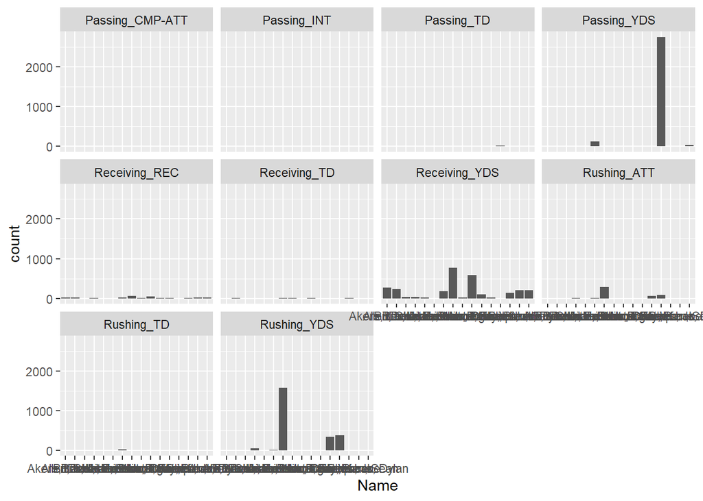

```r
library(dplyr)
library(ggplot2)


ggplot(offstat, aes(x=Name, weight=total)) + geom_bar() +
  facet_wrap(~stat)
```

It is very hard to see it because there are not much of a data, but you can see that the more you attempt(ATT) or receiving(REC) the more yards you get(YDS), and the more yards (YDS) the more you get touchdown (TD).

**4. Did ISU have better offense against Oregon or Oklahoma? Answer this question by creating a scatterplot with the x- and y-axes being the receiving yards of the ISU players against each of these two opponents. A large number of receiving yards indicates good offense.**

```r
library(dplyr)
library(ggplot2)

filtered_data <- tidy_offClean %>% filter(Opponent_Opponent %in% c("Oregon", "Oklahoma") & stat == "Receiving_YDS")
filtered_data
```

```
## # A tibble: 42 x 5
## # Groups:   Name, Opponent_Opponent [29]
##    Name               Opponent_Opponent num_game stat          value
##    <fct>              <fct>                <int> <chr>         <dbl>
##  1 Akers, Landen      Oklahoma                 1 Receiving_YDS    35
##  2 Akers, Landen      Oklahoma                 2 Receiving_YDS    25
##  3 Akers, Landen      Oregon                   1 Receiving_YDS    16
##  4 Brock, Jirehl      Oklahoma                 1 Receiving_YDS     0
##  5 Brock, Jirehl      Oklahoma                 2 Receiving_YDS     6
##  6 Brock, Jirehl      Oregon                   1 Receiving_YDS     0
##  7 Hutchinson, Xavier Oklahoma                 1 Receiving_YDS    83
##  8 Hutchinson, Xavier Oklahoma                 2 Receiving_YDS   114
##  9 Hutchinson, Xavier Oregon                   1 Receiving_YDS    45
## 10 Nwangwu, Kene      Oklahoma                 1 Receiving_YDS     0
## # ... with 32 more rows
```

```r
filtered_data <- filtered_data %>% group_by(Name, Opponent_Opponent) %>% summarize(
  meanval = mean(value)
)
#meanval <- visib_delay  %>% group_by(visib) %>% summarize("delay_mean" = mean(dep_delay, na.rm= TRUE))

filtered_data
```

```
## # A tibble: 29 x 3
## # Groups:   Name [15]
##    Name          Opponent_Opponent meanval
##    <fct>         <fct>               <dbl>
##  1 Akers, Landen Oklahoma               30
##  2 Akers, Landen Oregon                 16
##  3 Allen, Chase  Oklahoma               27
##  4 Allen, Chase  Oregon                 21
##  5 Bitter, Aidan Oklahoma                0
##  6 Bitter, Aidan Oregon                  0
##  7 Brock, Jirehl Oklahoma                3
##  8 Brock, Jirehl Oregon                  0
##  9 Dean, Easton  Oklahoma                0
## 10 Dean, Easton  Oregon                  0
## # ... with 19 more rows
```

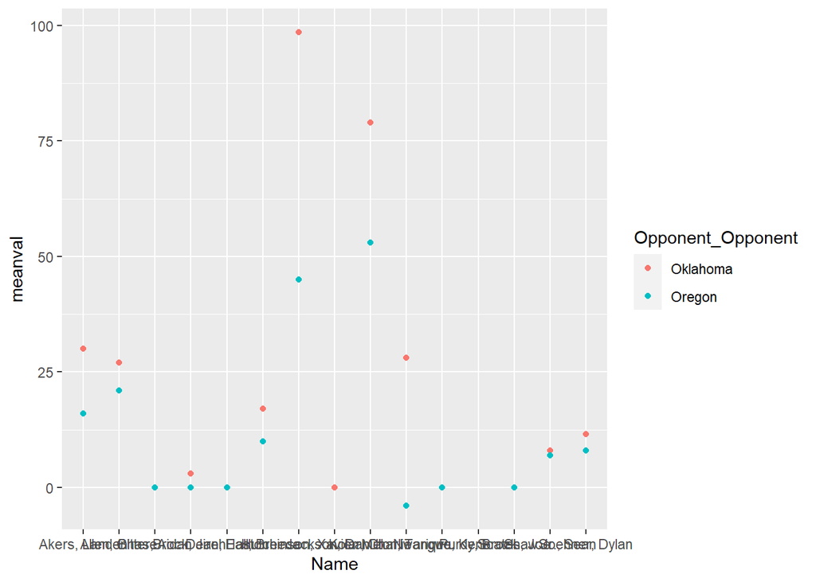

```r
ggplot(filtered_data, aes(x=Name ,y=meanval, color = Opponent_Opponent)) + geom_point()
```

It looks like ISU did better offense in against Oklahoma.

Now turn our attention to the player biography.

**5. Separate the Hometown column into two columns, namely, the city and the state where the player comes from. Print the first few rows of these two columns. (Hint: look at the sep= argument of separate)**

```r
library(dplyr)

bioClean <- bioClean %>% separate(Hometown, c('city','state'), sep = ',')
head(data_frame(bioClean$city,bioClean$state), 10)
```

```
## # A tibble: 10 x 2
##    `bioClean$city` `bioClean$state`
##    <chr>           <chr>
##  1 Cedar Rapids    " Iowa"
##  2 Nixa            " Mo."
##  3 Seffner         " Fla."
##  4 Ft. Lauderdale  " Fla."
##  5 Naperville      " Ill."
##  6 Grand Prairie   " Texas"
##  7 Clarksdale      " Miss."
##  8 Jacksonville    " Fla."
##  9 Jacksonville    " Fla."
## 10 Tampa           " Fla."
```

**6. How many players are there from each state?**

```r
library(dplyr)

num_players_by_state <- bioClean %>% group_by(state) %>% summarize(
  sum = n()
)
num_players_by_state
```

```
## # A tibble: 21 x 2
##    state          sum
##    <chr>        <int>
##  1 " Ariz."         4
##  2 " Ark."          1
##  3 " Australia"     1
##  4 " Calif."        2
##  5 " Fla."         14
##  6 " Ga."           3
##  7 " Ill."          6
##  8 " Iowa"         42
##  9 " Kan."          4
## 10 " Mich"          1
## # ... with 11 more rows
```

**7. How does the performance of quarterback Brock Purdy relate to the performance of the ISU team? Comment on both the defense and offense.**

```r
library(dplyr)
library(ggplot2)
off_PBrock <- offstat %>% filter(Name == "Purdy, Brock") %>% group_by(stat) %>% replace(is.na(.), 0) %>% summarize(
    indvtotal = sum(total)
  )

#def_Pbrock <- defClean %>% filter(Name == "Purdy, Brock")

off_PBrock
```

```
## # A tibble: 10 x 2
##    stat            indvtotal
##    <chr>               <dbl>
##  1 Passing_CMP-ATT         0
##  2 Passing_INT             9
##  3 Passing_TD             19
##  4 Passing_YDS          2750
##  5 Receiving_REC           0
##  6 Receiving_TD            0
##  7 Receiving_YDS           0
##  8 Rushing_ATT            87
##  9 Rushing_TD              5
## 10 Rushing_YDS           382
```

```r
offstat_team <- offstat %>% group_by(stat) %>% replace(is.na(.), 0) %>%
  summarize(
    teamtotal = sum(total)
  )
offstat_team
```

```
## # A tibble: 10 x 2
##    stat            teamtotal
##    <chr>               <dbl>
##  1 Passing_CMP-ATT         0
##  2 Passing_INT             9
##  3 Passing_TD             20
##  4 Passing_YDS          2896
##  5 Receiving_REC         242
##  6 Receiving_TD           19
##  7 Receiving_YDS        2845
##  8 Rushing_ATT           443
##  9 Rushing_TD             31
## 10 Rushing_YDS          2351
```

```r
joined_df <- offstat_team %>% left_join(off_PBrock, stat = stat) %>% pivot_longer(teamtotal:indvtotal, names_to = "indvteam", values_to = "value")
joined_df
```

```
## # A tibble: 20 x 3
##    stat            indvteam  value
##    <chr>           <chr>     <dbl>
##  1 Passing_CMP-ATT teamtotal     0
##  2 Passing_CMP-ATT indvtotal     0
##  3 Passing_INT     teamtotal     9
##  4 Passing_INT     indvtotal     9
##  5 Passing_TD      teamtotal    20
##  6 Passing_TD      indvtotal    19
##  7 Passing_YDS     teamtotal  2896
##  8 Passing_YDS     indvtotal  2750
##  9 Receiving_REC   teamtotal   242
## 10 Receiving_REC   indvtotal     0
## 11 Receiving_TD    teamtotal    19
## 12 Receiving_TD    indvtotal     0
## 13 Receiving_YDS   teamtotal  2845
## 14 Receiving_YDS   indvtotal     0
## 15 Rushing_ATT     teamtotal   443
## 16 Rushing_ATT     indvtotal    87
## 17 Rushing_TD      teamtotal    31
## 18 Rushing_TD      indvtotal     5
## 19 Rushing_YDS     teamtotal  2351
## 20 Rushing_YDS     indvtotal   382
```

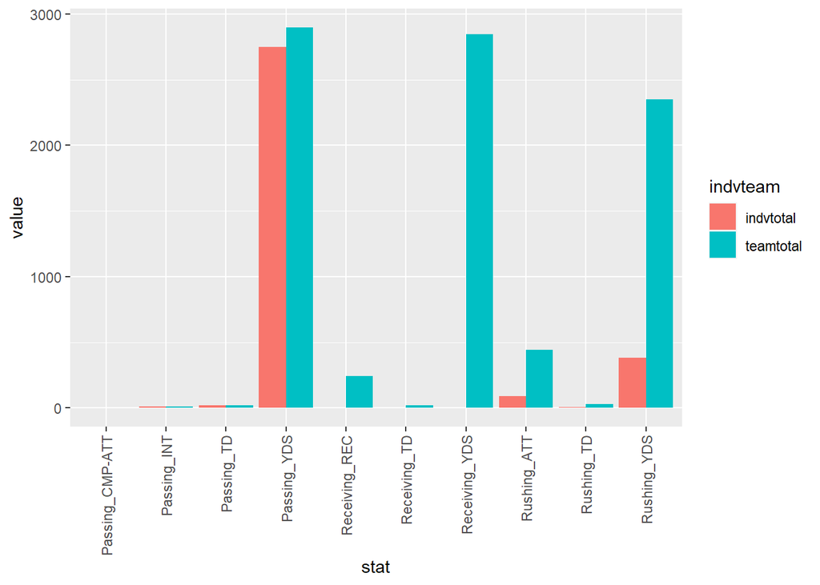

```r
ggplot(joined_df, aes(stat, value)) + geom_bar(aes(fill = indvteam), stat = "identity", position = "dodge") +theme(axis.text.x = element_text(angle = 90, vjust = 0.5, hjust=1))
```

For the offense, he greatly contributed on passing_int,and passing_yds. He somewhat contributed on rushing_att, rushing_YDS, and rusing_TD. I would say as a quarterback, he is doing great job on passing and making points. He is not too bad on rushing too, having some records to contributing touchdown.